# Итоговый проект по анализу данных

```r
library(tidyverse)
library(ggplot2)
library(gridExtra)
library(lmerTest)

setwd('C:/Users/irina/Documents/АНАЛИЗ ДАННЫХ/проект')

answers <- read_csv('answers.csv')
participants_info <- read_csv('participants_info.csv')
sentences <- read_csv('sentences.csv')
```

# Факторы, регулирующие эллипсис прямого объекта в русском языке

## 1. Введение

Тема проекта - “Факторы, регулирующие эллипсис прямого объекта в русском языке”. В рамках проекта исследовалось, влияет ли наличие отрицания и/или повелительное наклонение глагола, а также некоторые другие факторы на опущение прямого объекта в русском языке. Так, предполагалось, что предложение (2), содержащее отрицание, и (3), содержащее императив, могут оказаться для носителей более приемлемыми, чем предложение (1), т.е. опускать объект в условиях (2) и (3) лучше, чем в условии (1):

1. Петя постоянно просит (pro) о помощи, даже если может всё сделать сам.
2. Петя никогда не просит (pro) о помощи, если может всё сделать сам.
3. Лучше почаще проси (pro) о помощи, не мучайся сам!

Ранее (в моем мини-исследовании 2022 года) было выявлено, что такие факторы потенциально могут влиять на возможность депиктивов при опущенных прямых объектах - предложения (2) и (3) оказывались для носителей значительно лучше, чем (1):

1. Вася часто ест (pro) горячим.
2. Ну нельзя же есть (pro) сырым! Лучше подожди, пока я приготовлю.
3. Подожди, не ешь (pro) горячим, обожжешься!

Данное исследование пытается более аккуратно обойтись с переменными - в предыдущем я просто составляла стимулы рандомно, комбинируя разные условия, а сейчас я пытаюсь сделать их более контролируемыми, сбалансировать разные условия, добавить филлеры и т.д.

**Переменные:**

Зависимая переменная - средняя оценка приемлемости предложения носителями.

Переменные, которыми я манипулирую - синтаксический контекст предложения:

1. отрицание (принимает два значения - +neg, -neg)
2. императив (принимает два значения - +imp, -imp)
3. наличие упоминания этого же прямого объекта где-то еще в контексте (принимает два значения - +dobj, -dobj)
4. число глагола (sg, pl)

**Гипотезы исследования:**

**Неинтересные гипотезы:**

Гипотеза про участников:  
H0: средние оценки у людей с лингвистическим образованием и без лингвистического образования будут совпадать  
H1: средние оценки у людей с лингвистическим образованием и без лингвистического образования будут различаться

Гипотеза про предложения:  
H0: средние оценки филлеров и стимулов будут совпадать  
H1: средняя оценка филлеров будет выше средней оценки стимулов

**Интересные гипотезы - про факторы:**

Отрицание:  
H0: средняя оценка предложений с +neg равна средней оценке предложений с -neg  
H1: средняя оценка предложений с +neg больше средней оценки предложений с -neg

Императив:  
H0: средняя оценка предложений с +imp равна средней оценке предложений с -imp  
H1: средняя оценка предложений с +imp больше средней оценки предложений с -imp

Наличие упоминания прямого объекта:  
H0: средняя оценка предложений с +dobj равна средней оценке предложений с -dobj  
H1: средняя оценка предложений с +dobj больше средней оценки предложений с -dobj

Число глагола:  
H0: средняя оценка предложений с pl равна средней оценке предложений с sg  
H1: средняя оценка предложений с pl больше средней оценки предложений с sg

Подытоживания, **цель исследования** - выявить факторы, влияющие на опущение прямого объекта в русском языке, и основные гипотезы связаны с наличием зависимости оценок приемлемости предложения от конкретного фактора.

## 2. Метод

## 2.1. Данные

Все предложения:

```r
sentences
```

| type | sent_id | verb_id | verb | tran | aspect | sentence | obj_mentioned | number | imp | neg | combination | variant |
| --- | --- | --- | --- | --- | --- | --- | --- | --- | --- | --- | --- | --- |
| target | 1 | 1 | просить | tran | imperf | Петя постоянно просит о помощи, даже если может всё сделать сам. | 0 | sg | 0 | 0 | 1 | 1 |
| target | 2 | 1 | просить | tran | imperf | Петя никогда не просит о помощи, если может всё сделать сам. | 0 | sg | 0 | 1 | 2 | 2 |
| target | 3 | 1 | просить | tran | imperf | Лучше почаще проси о помощи, не мучайся сам! | 0 | sg | 1 | 0 | 3 | 3 |
| target | 4 | 1 | просить | tran | imperf | Никогда не проси о помощи, лучше делай всё сам! | 0 | sg | 1 | 1 | 4 | 4 |
| target | 5 | 2 | строить | tran | imperf | На таких территориях часто строят, они отлично для этого подходят. | 0 | pl | 0 | 0 | 1 | 1 |
| target | 6 | 2 | строить | tran | imperf | Обычно на таких территориях не строят, это слишком рискованно. | 0 | pl | 0 | 1 | 2 | 2 |
| target | 7 | 2 | строить | tran | imperf | Стройте здесь, эта территория отлично для этого подходит. | 0 | pl | 1 | 0 | 3 | 3 |
| target | 8 | 2 | строить | tran | imperf | Не стройте здесь, это частная территория. | 0 | pl | 1 | 1 | 4 | 4 |
| target | 9 | 3 | брать | tran | imperf | Когда мне предлагают шоколадки, я обычно беру. | 1 | sg | 0 | 0 | 1 | 1 |
| target | 10 | 3 | брать | tran | imperf | Когда мне предлагают шоколадки, я никогда не беру. | 1 | sg | 0 | 1 | 2 | 2 |

[output cut: 70 more lines]

Балансировалось количество предложений с разными значениями одного и того же фактора:

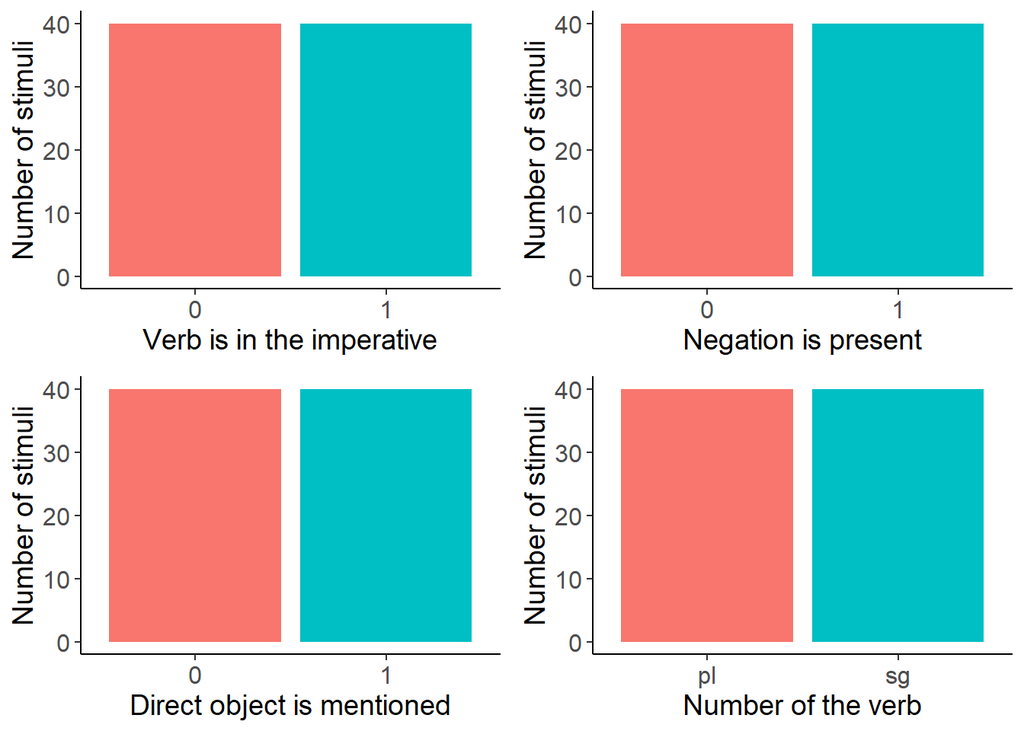

```r
sentences <- sentences %>%
  mutate(obj_mentioned = as.factor(obj_mentioned)) %>%
  mutate(imp = as.factor(imp)) %>%
  mutate(neg = as.factor(neg)) %>%
  mutate(combination = as.factor(combination))

obj_plot <- sentences %>%
  ggplot(aes(x = obj_mentioned, fill = obj_mentioned)) +
  geom_bar() +
  theme_classic() +
  labs(x = 'Direct object is mentioned', y = 'Number of stimuli') +
  theme(axis.title.x = element_text(size = 14),
        axis.title.y = element_text(size = 14),
        axis.text.x = element_text(size = 12),
        axis.text.y = element_text(size = 12),
        plot.title = element_text(hjust = 0.5, size = 12),
        legend.position = "none")

imp_plot <- sentences %>%
  ggplot(aes(x = imp, fill = imp)) +
  geom_bar() +
  theme_classic() +
  labs(x = 'Verb is in the imperative', y = 'Number of stimuli') +
  theme(axis.title.x = element_text(size = 14),
        axis.title.y = element_text(size = 14),
        axis.text.x = element_text(size = 12),
        axis.text.y = element_text(size = 12),
        plot.title = element_text(hjust = 0.5, size = 12),
        legend.position = "none")

neg_plot <- sentences %>%
  ggplot(aes(x = neg, fill = neg)) +
  geom_bar() +
  theme_classic() +
  labs(x = 'Negation is present', y = 'Number of stimuli') +
  theme(axis.title.x = element_text(size = 14),
        axis.title.y = element_text(size = 14),
        axis.text.x = element_text(size = 12),
        axis.text.y = element_text(size = 12),
        plot.title = element_text(hjust = 0.5, size = 12),
        legend.position = "none")

numb_plot <- sentences %>%
  ggplot(aes(x = number, fill = number)) +
  geom_bar() +
  theme_classic() +
  labs(x = 'Number of the verb', y = 'Number of stimuli') +
  theme(axis.title.x = element_text(size = 14),
        axis.title.y = element_text(size = 14),
        axis.text.x = element_text(size = 12),
        axis.text.y = element_text(size = 12),
        plot.title = element_text(hjust = 0.5, size = 12),
        legend.position = "none")


grid.arrange(imp_plot, neg_plot,
             obj_plot, numb_plot,
             ncol = 2)
```

Среди предложений было 16 филлеров:

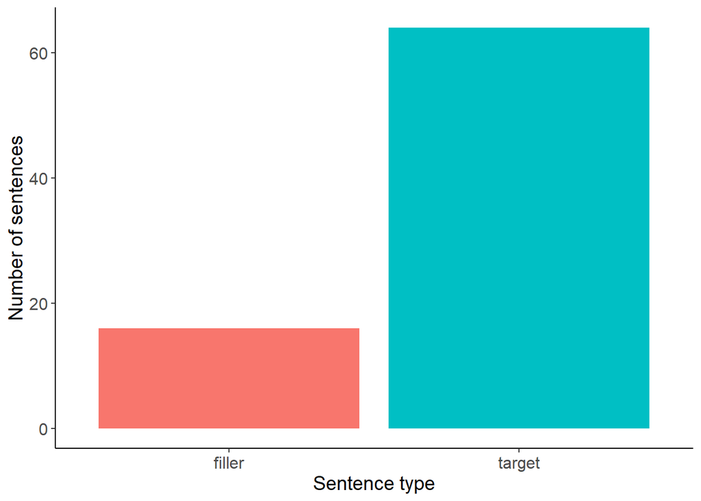

```r
sentences %>%
  ggplot(aes(x = type, fill = type)) +
  geom_bar() +
  theme_classic() +
  labs(x = 'Sentence type', y = 'Number of sentences') +
  theme(axis.title.x = element_text(size = 14),
        axis.title.y = element_text(size = 14),
        axis.text.x = element_text(size = 12),
        axis.text.y = element_text(size = 12),
        plot.title = element_text(hjust = 0.5, size = 12),
        legend.position = "none")
```

Среди филлеров половина содержала переходные глаголы, половина - непереходные:

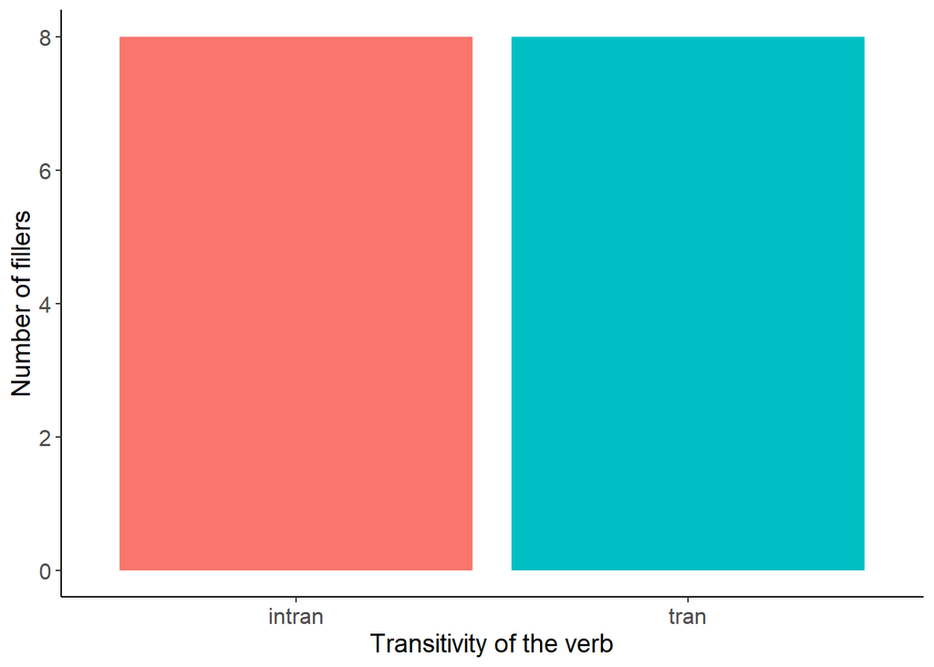

```r
sentences %>%
  filter(type == 'filler') %>%
  ggplot(aes(x = tran, fill = tran)) +
  geom_bar() +
  theme_classic() +
  labs(x = 'Transitivity of the verb', y = 'Number of fillers') +
  theme(axis.title.x = element_text(size = 14),
        axis.title.y = element_text(size = 14),
        axis.text.x = element_text(size = 12),
        axis.text.y = element_text(size = 12),
        plot.title = element_text(hjust = 0.5, size = 12),
        legend.position = "none")
```

## 2.2. Процедура

Все предложения были разбиты на 4 стимульных листа. В каждом было 16 таргетных предложений и 16 филлеров. Эксперимент проходил в гугл-формах. Участникам нужно было оценить предложение, дав ему оценку на шкале от 1 до 5, где оценка “1” означала, что предложение звучит очень плохо и участник никогда бы так не сказал, а “5” - что предложение звучит отлично и участник мог бы сам так сказать.

## 2.3. Участники

Собиралась следующая информация: возраст, наличие лингвистического образования, город, а также наличие других родных языков помимо русского.

Про участников:

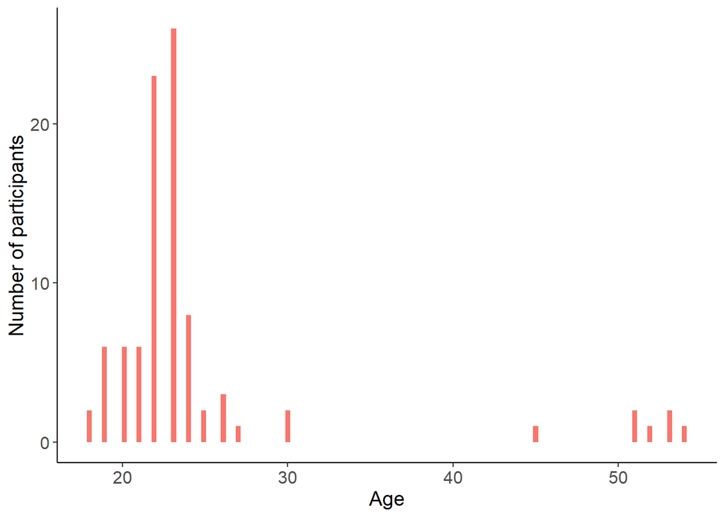

```r
participants_info %>%
  ggplot(aes(x = `Сколько вам полных лет?`, fill = 'red')) +
  geom_histogram(binwidth = 0.3) +
  theme_classic() +
  labs(x = 'Age', y = 'Number of participants') +
  theme(axis.title.x = element_text(size = 14),
        axis.title.y = element_text(size = 14),
        axis.text.x = element_text(size = 12),
        axis.text.y = element_text(size = 12),
        plot.title = element_text(hjust = 0.5, size = 12),
        legend.position = "none")
```

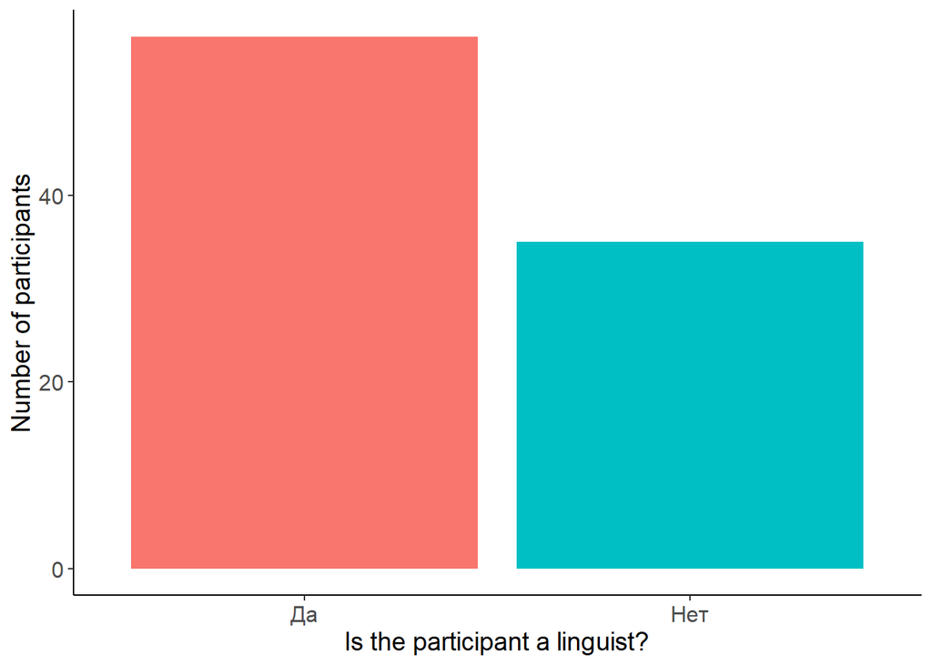

```r
participants_info %>%
  ggplot(aes(x = `Есть ли у вас лингвистическое образование?`, fill = `Есть ли у вас лингвистическое образование?`)) +
  geom_bar() +
  theme_classic() +
  labs(x = 'Is the participant a linguist?', y = 'Number of participants') +
  theme(axis.title.x = element_text(size = 14),
        axis.title.y = element_text(size = 14),
        axis.text.x = element_text(size = 12),
        axis.text.y = element_text(size = 12),
        plot.title = element_text(hjust = 0.5, size = 12),
        legend.position = "none")
```

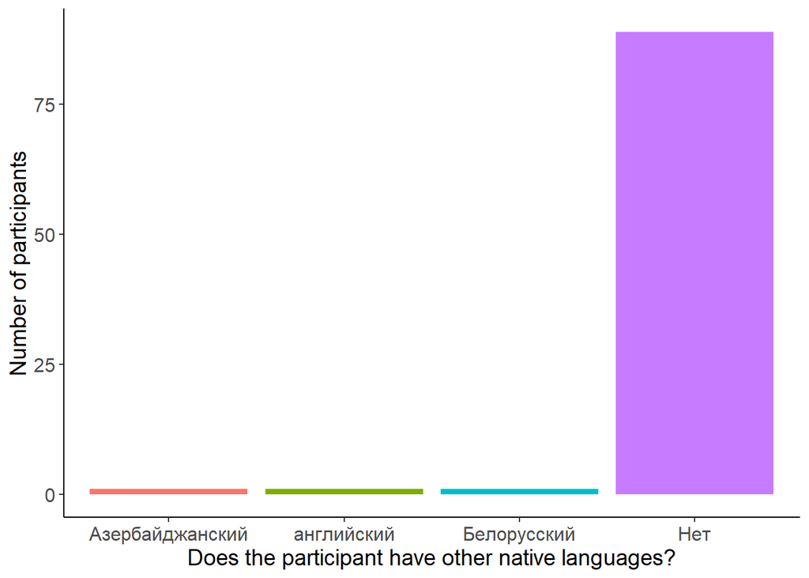

```r
participants_info %>%
  ggplot(aes(x = `Есть ли у вас другие родные языки, помимо русского?`, fill = `Есть ли у вас другие родные языки, помимо русского?`)) +
  geom_bar() +
  theme_classic() +
  labs(x = 'Does the participant have other native languages?', y = 'Number of participants') +
  theme(axis.title.x = element_text(size = 14),
        axis.title.y = element_text(size = 14),
        axis.text.x = element_text(size = 12),
        axis.text.y = element_text(size = 12),
        plot.title = element_text(hjust = 0.5, size = 12),
        legend.position = "none")
```

[figure not shown]

```r
participants_info %>%
  ggplot(aes(x = city_pure, fill = city_pure)) +
  geom_bar() +
  theme_classic() +
  labs(x = 'City', y = 'Number of participants') +
  theme(axis.title.x = element_text(size = 14),
        axis.title.y = element_text(size = 14),
        axis.text.x = element_text(size = 12),
        axis.text.y = element_text(size = 12),
        plot.title = element_text(hjust = 0.5, size = 12),
        legend.position = "none")
```

# 3. Результаты

Некоторый препроцессинг:

```r
answers_longer <- answers %>%
  pivot_longer(cols = 2:129) %>%
  rename(sentence = name, score = value)

answers_longer$sentence <- str_replace_all(answers_longer$sentence, regex('...[0-9]+'), '')

summary <- answers_longer %>%
  na.omit() %>%
  group_by(sentence) %>%
  summarize(score = mean(score))

answers_longer <- answers_longer %>%
  na.omit()

everything <- merge(answers_longer, participants_info,
                    by.x = 'participant_id', by.y = 'participant_id') %>%
  select(participant_id, sentence, score, `Есть ли у вас лингвистическое образование?`) %>%
  rename(is_linguist = `Есть ли у вас лингвистическое образование?`)

everything <- merge(everything, sentences,
                    by.x = 'sentence', by.y = 'sentence')

targets <- everything %>%
  filter(type == 'target')

summary_all <- merge(summary, sentences,
                     by.x = 'sentence', by.y = 'sentence')

sum_targets <- summary_all %>%
  filter(type == 'target') %>%
  mutate(obj_mentioned = as.factor(obj_mentioned)) %>%
  mutate(imp = as.factor(imp)) %>%
  mutate(neg = as.factor(neg)) %>%
  mutate(combination = as.factor(combination))

everything
```

| sentence | participant_id | score | is_linguist | type | sent_id | verb_id | verb | tran | aspect | obj_mentioned | number | imp | neg | combination | variant |
| --- | --- | --- | --- | --- | --- | --- | --- | --- | --- | --- | --- | --- | --- | --- | --- |
| Вчера мои родители порадовали меня вкуснейшей едой. | participant87 | 4 | Нет | filler | 77 | 0 | порадовать | tran | perf | 1 | pl | 0 | 0 | 1 | 0 |
| Вчера мои родители порадовали меня вкуснейшей едой. | participant65 | 5 | Да | filler | 77 | 0 | порадовать | tran | perf | 1 | pl | 0 | 0 | 1 | 0 |
| Вчера мои родители порадовали меня вкуснейшей едой. | participant55 | 5 | Нет | filler | 77 | 0 | порадовать | tran | perf | 1 | pl | 0 | 0 | 1 | 0 |
| Вчера мои родители порадовали меня вкуснейшей едой. | participant21 | 5 | Да | filler | 77 | 0 | порадовать | tran | perf | 1 | pl | 0 | 0 | 1 | 0 |
| Вчера мои родители порадовали меня вкуснейшей едой. | participant49 | 5 | Да | filler | 77 | 0 | порадовать | tran | perf | 1 | pl | 0 | 0 | 1 | 0 |
| Вчера мои родители порадовали меня вкуснейшей едой. | participant61 | 2 | Да | filler | 77 | 0 | порадовать | tran | perf | 1 | pl | 0 | 0 | 1 | 0 |
| Вчера мои родители порадовали меня вкуснейшей едой. | participant83 | 4 | Нет | filler | 77 | 0 | порадовать | tran | perf | 1 | pl | 0 | 0 | 1 | 0 |
| Вчера мои родители порадовали меня вкуснейшей едой. | participant13 | 5 | Да | filler | 77 | 0 | порадовать | tran | perf | 1 | pl | 0 | 0 | 1 | 0 |
| Вчера мои родители порадовали меня вкуснейшей едой. | participant30 | 5 | Да | filler | 77 | 0 | порадовать | tran | perf | 1 | pl | 0 | 0 | 1 | 0 |
| Вчера мои родители порадовали меня вкуснейшей едой. | participant48 | 5 | Нет | filler | 77 | 0 | порадовать | tran | perf | 1 | pl | 0 | 0 | 1 | 0 |

[output cut: 2934 more lines]

## 3.1. Проверка неинтересных гипотез

Сравнение ответов лингвистов и не-лингвистов:

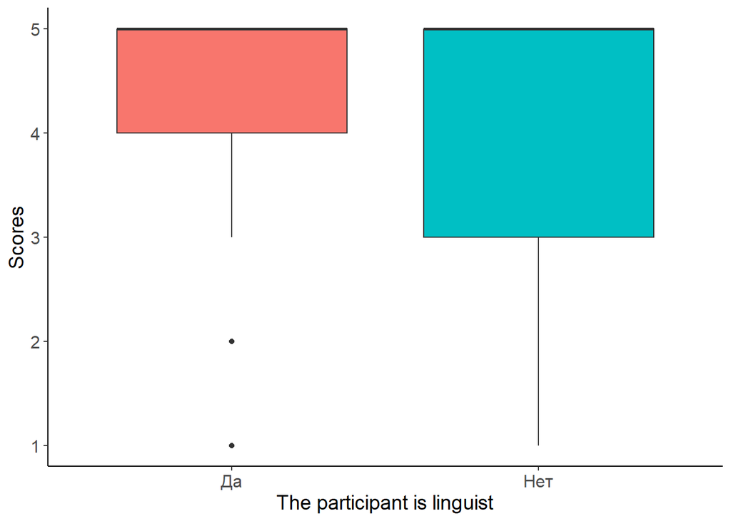

```r
everything %>%
  ggplot(aes(x = is_linguist, y = score, fill = is_linguist)) +
  geom_boxplot() +
  theme_classic() +
  labs(x = 'The participant is linguist', y = 'Scores') +
  theme(axis.title.x = element_text(size = 14),
        axis.title.y = element_text(size = 14),
        axis.text.x = element_text(size = 12),
        axis.text.y = element_text(size = 12),
        plot.title = element_text(hjust = 0.5, size = 12),
        legend.position = "none")
```

```r
shapiro.test(filter(everything, is_linguist == 'Да')$score)
```

```
##
##  Shapiro-Wilk normality test
##
## data:  filter(everything, is_linguist == "Да")$score
## W = 0.68803, p-value < 2.2e-16
```

```r
shapiro.test(filter(everything, is_linguist == 'Нет')$score)
```

```
##
##  Shapiro-Wilk normality test
##
## data:  filter(everything, is_linguist == "Нет")$score
## W = 0.74782, p-value < 2.2e-16
```

```r
wilcox.test(everything$score ~ everything$is_linguist)
```

```
##
##  Wilcoxon rank sum test with continuity correction
##
## data:  everything$score by everything$is_linguist
## W = 1116397, p-value = 1.727e-06
## alternative hypothesis: true location shift is not equal to 0
```

Оценки, данные лингвистами и не-лингвистами, значимо различаются (p < 0.001). Лингвисты в среднем оценивают предложения как более грамматичные, чем не-лингвисты.

Сравнение филлеров и таргетов:

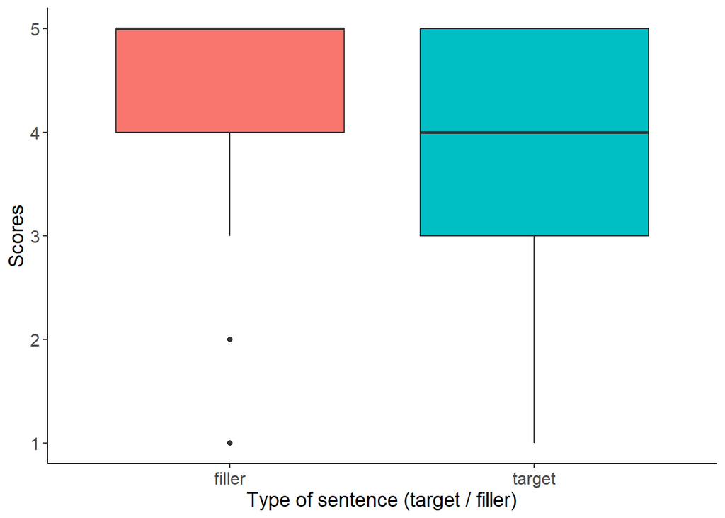

```r
everything %>%
  ggplot(aes(x = type, y = score, fill = type)) +
  geom_boxplot() +
  theme_classic() +
  labs(x = 'Type of sentence (target / filler)', y = 'Scores') +
  theme(axis.title.x = element_text(size = 14),
        axis.title.y = element_text(size = 14),
        axis.text.x = element_text(size = 12),
        axis.text.y = element_text(size = 12),
        plot.title = element_text(hjust = 0.5, size = 12),
        legend.position = "none")
```

```r
shapiro.test(filter(everything, type == 'target')$score)
```

```
##
##  Shapiro-Wilk normality test
##
## data:  filter(everything, type == "target")$score
## W = 0.79916, p-value < 2.2e-16
```

```r
shapiro.test(filter(everything, type == 'filler')$score)
```

```
##
##  Shapiro-Wilk normality test
##
## data:  filter(everything, type == "filler")$score
## W = 0.59511, p-value < 2.2e-16
```

```r
wilcox.test(filter(everything, type == 'target')$score,
       filter(everything, type == 'filler')$score,
       alternative = 'less')
```

```
##
##  Wilcoxon rank sum test with continuity correction
##
## data:  filter(everything, type == "target")$score and filter(everything, type == "filler")$score
## W = 775973, p-value < 2.2e-16
## alternative hypothesis: true location shift is less than 0
```

Средняя оценка филлеров значимо выше средней оценки стимулов (p < 0.001).

## 3.2. Проверка интересных гипотез

### 3.2.1. Отрицание

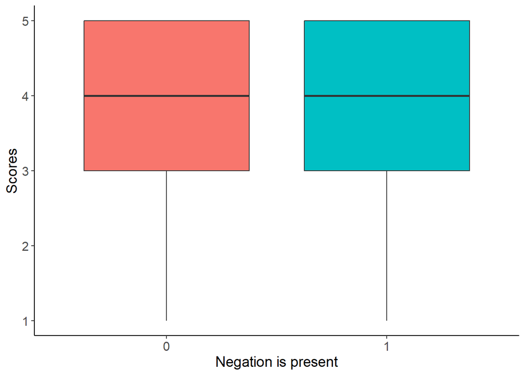

```r
targets %>%
  ggplot(aes(x = neg, y = score, fill = neg)) +
  geom_boxplot() +
  theme_classic() +
  labs(x = 'Negation is present', y = 'Scores') +
  theme(axis.title.x = element_text(size = 14),
        axis.title.y = element_text(size = 14),
        axis.text.x = element_text(size = 12),
        axis.text.y = element_text(size = 12),
        plot.title = element_text(hjust = 0.5, size = 12),
        legend.position = "none")
```

```r
shapiro.test(filter(targets, neg == 0)$score)
```

```
##
##  Shapiro-Wilk normality test
##
## data:  filter(targets, neg == 0)$score
## W = 0.80465, p-value < 2.2e-16
```

```r
shapiro.test(filter(targets, neg == 1)$score)
```

```
##
##  Shapiro-Wilk normality test
##
## data:  filter(targets, neg == 1)$score
## W = 0.79323, p-value < 2.2e-16
```

```r
wilcox.test(filter(targets, neg == 0)$score,
       filter(targets, neg == 1)$score,
       alternative = 'less')
```

```
##
##  Wilcoxon rank sum test with continuity correction
##
## data:  filter(targets, neg == 0)$score and filter(targets, neg == 1)$score
## W = 266391, p-value = 0.2805
## alternative hypothesis: true location shift is less than 0
```

Только средние значения для предложений:

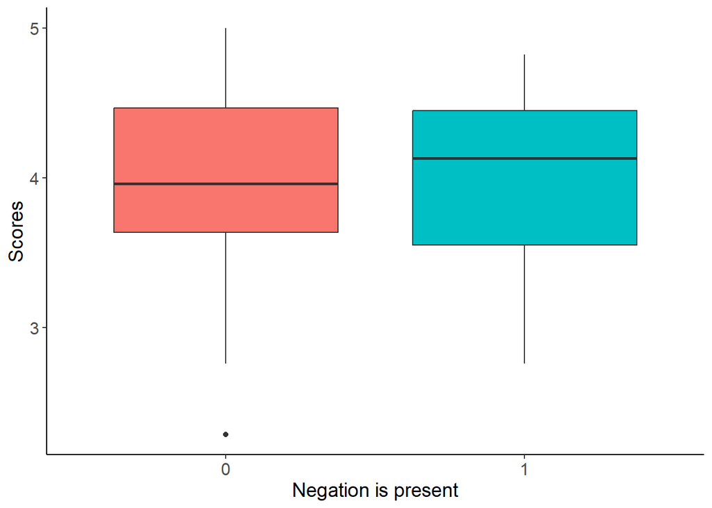

```r
sum_targets %>%
  ggplot(aes(x = neg, y = score, fill = neg)) +
  geom_boxplot() +
  theme_classic() +
  labs(x = 'Negation is present', y = 'Scores') +
  theme(axis.title.x = element_text(size = 14),
        axis.title.y = element_text(size = 14),
        axis.text.x = element_text(size = 12),
        axis.text.y = element_text(size = 12),
        plot.title = element_text(hjust = 0.5, size = 12),
        legend.position = "none")
```

```r
shapiro.test(filter(sum_targets, neg == 0)$score)
```

```
##
##  Shapiro-Wilk normality test
##
## data:  filter(sum_targets, neg == 0)$score
## W = 0.96687, p-value = 0.4177
```

```r
shapiro.test(filter(sum_targets, neg == 1)$score)
```

```
##
##  Shapiro-Wilk normality test
##
## data:  filter(sum_targets, neg == 1)$score
## W = 0.93713, p-value = 0.0621
```

```r
t.test(filter(sum_targets, neg == 0)$score,
       filter(sum_targets, neg == 1)$score,
       alternative = 'less')
```

```
##
##  Welch Two Sample t-test
##
## data:  filter(sum_targets, neg == 0)$score and filter(sum_targets, neg == 1)$score
## t = -0.28575, df = 61.996, p-value = 0.388
## alternative hypothesis: true difference in means is less than 0
## 95 percent confidence interval:
##       -Inf 0.2138868
## sample estimates:
## mean of x mean of y
##  3.950685  3.994844
```

Таким образом, наличие отрицания не влияет на приемлемость (p = 0.28 и p = 0.39).

### 3.2.2. Императив

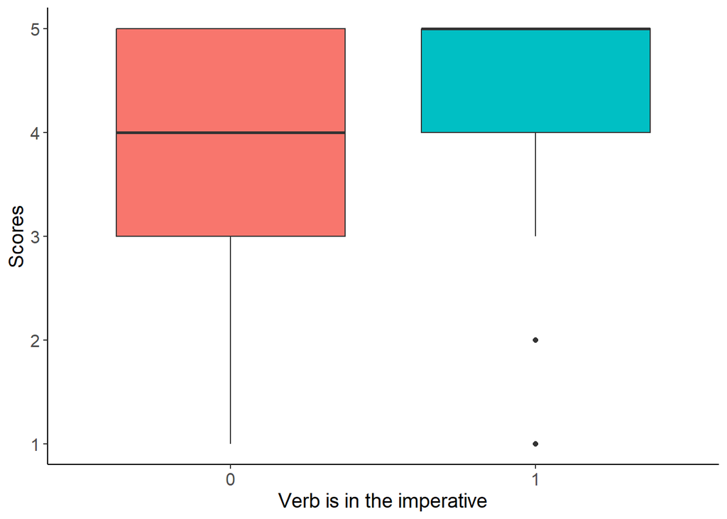

```r
targets %>%
  ggplot(aes(x = imp, y = score, fill = imp)) +
  geom_boxplot() +
  theme_classic() +
  labs(x = 'Verb is in the imperative', y = 'Scores') +
  theme(axis.title.x = element_text(size = 14),
        axis.title.y = element_text(size = 14),
        axis.text.x = element_text(size = 12),
        axis.text.y = element_text(size = 12),
        plot.title = element_text(hjust = 0.5, size = 12),
        legend.position = "none")
```

```r
shapiro.test(filter(targets, imp == 0)$score)
```

```
##
##  Shapiro-Wilk normality test
##
## data:  filter(targets, imp == 0)$score
## W = 0.86319, p-value < 2.2e-16
```

```r
shapiro.test(filter(targets, imp == 1)$score)
```

```
##
##  Shapiro-Wilk normality test
##
## data:  filter(targets, imp == 1)$score
## W = 0.70711, p-value < 2.2e-16
```

```r
wilcox.test(filter(targets, imp == 0)$score,
       filter(targets, imp == 1)$score,
       alternative = 'less')
```

```
##
##  Wilcoxon rank sum test with continuity correction
##
## data:  filter(targets, imp == 0)$score and filter(targets, imp == 1)$score
## W = 184972, p-value < 2.2e-16
## alternative hypothesis: true location shift is less than 0
```

Только средние значения для предложений:

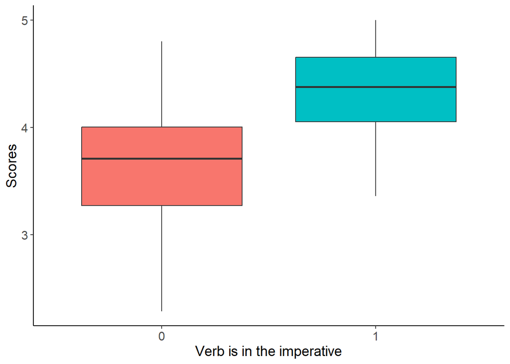

```r
sum_targets %>%
  ggplot(aes(x = imp, y = score, fill = imp)) +
  geom_boxplot() +
  theme_classic() +
  labs(x = 'Verb is in the imperative', y = 'Scores') +
  theme(axis.title.x = element_text(size = 14),
        axis.title.y = element_text(size = 14),
        axis.text.x = element_text(size = 12),
        axis.text.y = element_text(size = 12),
        plot.title = element_text(hjust = 0.5, size = 12),
        legend.position = "none")
```

```r
shapiro.test(filter(sum_targets, imp == 0)$score)
```

```
##
##  Shapiro-Wilk normality test
##
## data:  filter(sum_targets, imp == 0)$score
## W = 0.9805, p-value = 0.8141
```

```r
shapiro.test(filter(sum_targets, imp == 1)$score)
```

```
##
##  Shapiro-Wilk normality test
##
## data:  filter(sum_targets, imp == 1)$score
## W = 0.96362, p-value = 0.3439
```

```r
t.test(filter(sum_targets, imp == 0)$score,
       filter(sum_targets, imp == 1)$score,
       alternative = 'less')
```

```
##
##  Welch Two Sample t-test
##
## data:  filter(sum_targets, imp == 0)$score and filter(sum_targets, imp == 1)$score
## t = -4.8673, df = 56.261, p-value = 4.769e-06
## alternative hypothesis: true difference in means is less than 0
## 95 percent confidence interval:
##        -Inf -0.4202505
## sample estimates:
## mean of x mean of y
##  3.652649  4.292879
```

Таким образом, наличие императива значимо влияет на приемлемость (p < 0.001 в обоих случаях).

### 3.2.3. Упоминание прямого объекта

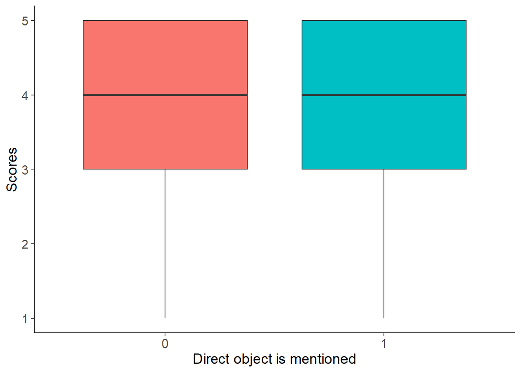

```r
targets %>%
  ggplot(aes(x = obj_mentioned, y = score, fill = obj_mentioned)) +
  geom_boxplot() +
  theme_classic() +
  labs(x = 'Direct object is mentioned', y = 'Scores') +
  theme(axis.title.x = element_text(size = 14),
        axis.title.y = element_text(size = 14),
        axis.text.x = element_text(size = 12),
        axis.text.y = element_text(size = 12),
        plot.title = element_text(hjust = 0.5, size = 12),
        legend.position = "none")
```

```r
shapiro.test(filter(targets, obj_mentioned == 0)$score)
```

```
##
##  Shapiro-Wilk normality test
##
## data:  filter(targets, obj_mentioned == 0)$score
## W = 0.78789, p-value < 2.2e-16
```

```r
shapiro.test(filter(targets, obj_mentioned == 1)$score)
```

```
##
##  Shapiro-Wilk normality test
##
## data:  filter(targets, obj_mentioned == 1)$score
## W = 0.80916, p-value < 2.2e-16
```

```r
wilcox.test(filter(targets, obj_mentioned == 0)$score,
       filter(targets, obj_mentioned == 1)$score,
       alternative = 'less')
```

```
##
##  Wilcoxon rank sum test with continuity correction
##
## data:  filter(targets, obj_mentioned == 0)$score and filter(targets, obj_mentioned == 1)$score
## W = 278543, p-value = 0.8422
## alternative hypothesis: true location shift is less than 0
```

Только средние значения для предложений:

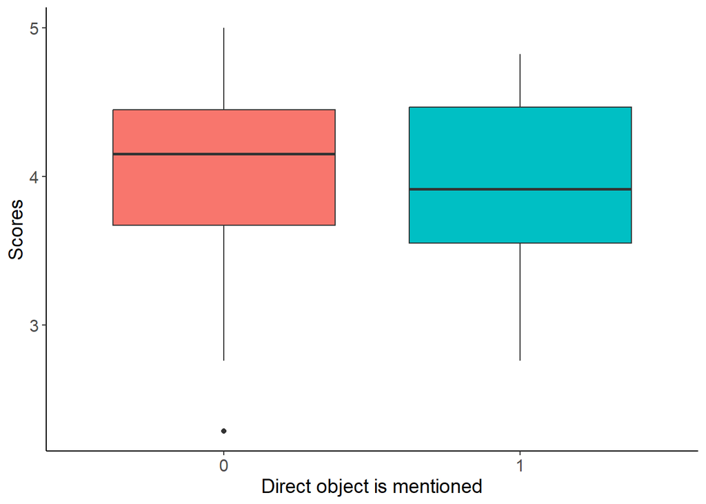

```r
sum_targets %>%
  ggplot(aes(x = obj_mentioned, y = score, fill = obj_mentioned)) +
  geom_boxplot() +
  theme_classic() +
  labs(x = 'Direct object is mentioned', y = 'Scores') +
  theme(axis.title.x = element_text(size = 14),
        axis.title.y = element_text(size = 14),
        axis.text.x = element_text(size = 12),
        axis.text.y = element_text(size = 12),
        plot.title = element_text(hjust = 0.5, size = 12),
        legend.position = "none")
```

```r
shapiro.test(filter(sum_targets, obj_mentioned == 0)$score)
```

```
##
##  Shapiro-Wilk normality test
##
## data:  filter(sum_targets, obj_mentioned == 0)$score
## W = 0.94156, p-value = 0.08289
```

```r
shapiro.test(filter(sum_targets, obj_mentioned == 1)$score)
```

```
##
##  Shapiro-Wilk normality test
##
## data:  filter(sum_targets, obj_mentioned == 1)$score
## W = 0.96391, p-value = 0.3501
```

```r
t.test(filter(sum_targets, obj_mentioned == 0)$score,
       filter(sum_targets, obj_mentioned == 1)$score,
       alternative = 'less')
```

```
##
##  Welch Two Sample t-test
##
## data:  filter(sum_targets, obj_mentioned == 0)$score and filter(sum_targets, obj_mentioned == 1)$score
## t = 0.30388, df = 61.184, p-value = 0.6189
## alternative hypothesis: true difference in means is less than 0
## 95 percent confidence interval:
##       -Inf 0.3050326
## sample estimates:
## mean of x mean of y
##  3.996243  3.949286
```

Таким образом, наличие упоминания прямого объекта в контексте не влияет на приемлемость (p = 0.84 и p = 0.62).

### 3.2.4. Число глагола

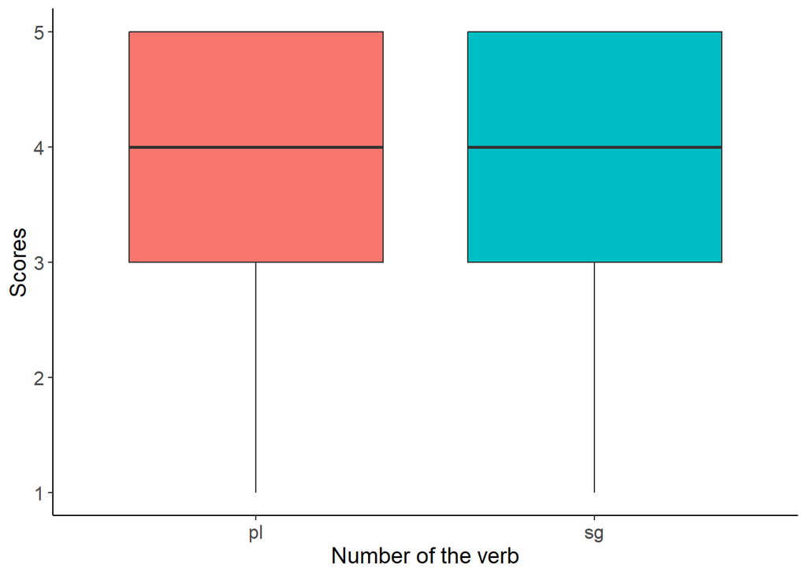

```r
targets %>%
  ggplot(aes(x = number, y = score, fill = number)) +
  geom_boxplot() +
  theme_classic() +
  labs(x = 'Number of the verb', y = 'Scores') +
  theme(axis.title.x = element_text(size = 14),
        axis.title.y = element_text(size = 14),
        axis.text.x = element_text(size = 12),
        axis.text.y = element_text(size = 12),
        plot.title = element_text(hjust = 0.5, size = 12),
        legend.position = "none")
```

```r
shapiro.test(filter(targets, number == 'sg')$score)
```

```
##
##  Shapiro-Wilk normality test
##
## data:  filter(targets, number == "sg")$score
## W = 0.79592, p-value < 2.2e-16
```

```r
shapiro.test(filter(targets, number == 'pl')$score)
```

```
##
##  Shapiro-Wilk normality test
##
## data:  filter(targets, number == "pl")$score
## W = 0.80224, p-value < 2.2e-16
```

```r
wilcox.test(filter(targets, number == 'sg')$score,
       filter(targets, number == 'pl')$score,
       alternative = 'less')
```

```
##
##  Wilcoxon rank sum test with continuity correction
##
## data:  filter(targets, number == "sg")$score and filter(targets, number == "pl")$score
## W = 268896, p-value = 0.3996
## alternative hypothesis: true location shift is less than 0
```

Только средние значения для предложений:

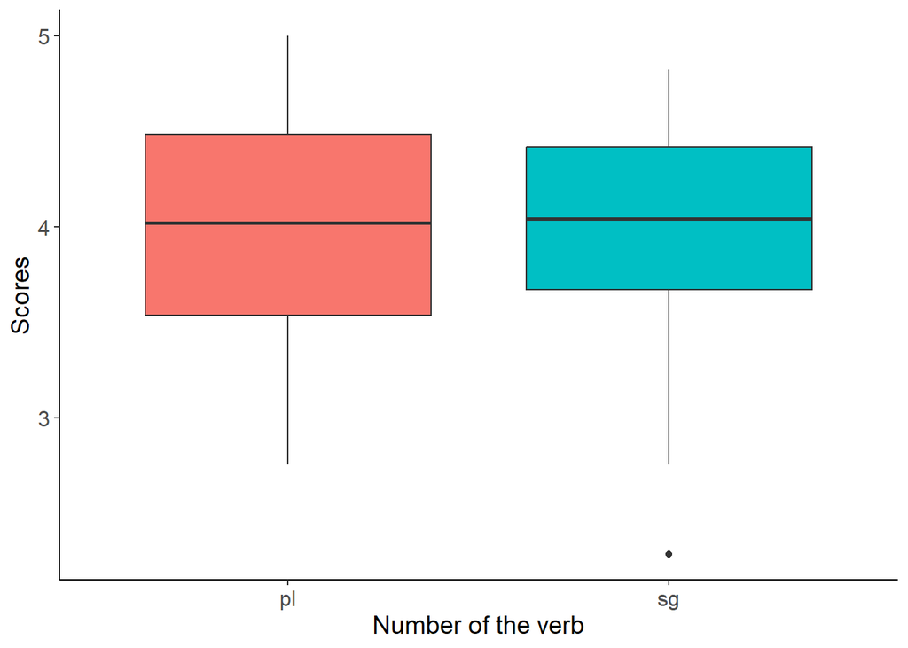

```r
sum_targets %>%
  ggplot(aes(x = number, y = score, fill = number)) +
  geom_boxplot() +
  theme_classic() +
  labs(x = 'Number of the verb', y = 'Scores') +
  theme(axis.title.x = element_text(size = 14),
        axis.title.y = element_text(size = 14),
        axis.text.x = element_text(size = 12),
        axis.text.y = element_text(size = 12),
        plot.title = element_text(hjust = 0.5, size = 12),
        legend.position = "none")
```

```r
shapiro.test(filter(sum_targets, number == 'sg')$score)
```

```
##
##  Shapiro-Wilk normality test
##
## data:  filter(sum_targets, number == "sg")$score
## W = 0.92476, p-value = 0.02804
```

```r
shapiro.test(filter(sum_targets, number == 'pl')$score)
```

```
##
##  Shapiro-Wilk normality test
##
## data:  filter(sum_targets, number == "pl")$score
## W = 0.96651, p-value = 0.4091
```

```r
wilcox.test(filter(sum_targets, number == 'sg')$score,
       filter(sum_targets, number == 'pl')$score,
       alternative = 'less')
```

```
##
##  Wilcoxon rank sum test with continuity correction
##
## data:  filter(sum_targets, number == "sg")$score and filter(sum_targets, number == "pl")$score
## W = 493, p-value = 0.4019
## alternative hypothesis: true location shift is less than 0
```

Таким образом, число глагола не влияет на приемлемость (p = 0.40 в обоих случаях).

### 3.2.5. Комбинация отрицания и императива: ANOVA

В действительности в данных были 4 комбинации стимулов - +-neg, +-imp. Посмотрим, есть ли между комбинациями значимые различия, и если есть, то между какими из них.

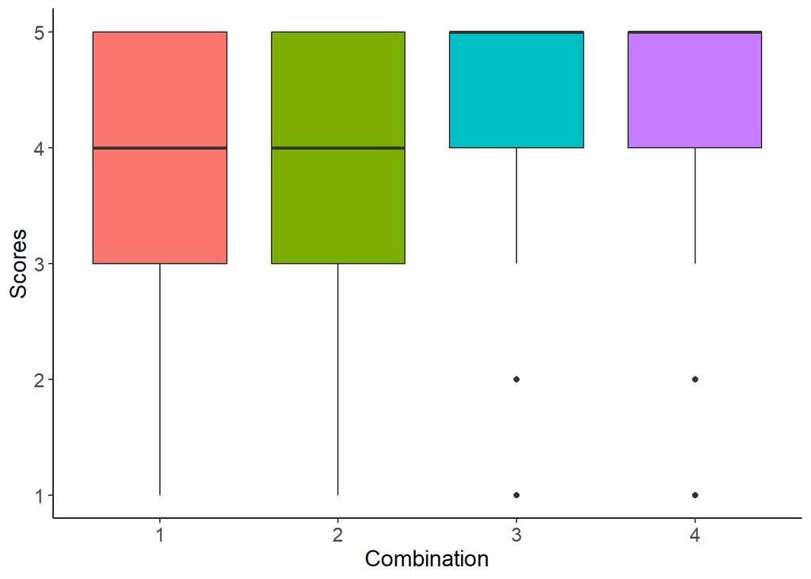

```r
targets %>%
  ggplot(aes(x = combination, y = score, fill = combination)) +
  geom_boxplot() +
  theme_classic() +
  labs(x = 'Combination', y = 'Scores') +
  theme(axis.title.x = element_text(size = 14),
        axis.title.y = element_text(size = 14),
        axis.text.x = element_text(size = 12),
        axis.text.y = element_text(size = 12),
        plot.title = element_text(hjust = 0.5, size = 12),
        legend.position = "none")
```

```r
aov_model <- aov(targets$score ~ targets$combination)
summary(aov_model)
```

```
##                       Df Sum Sq Mean Sq F value Pr(>F)
## targets$combination    3  187.3   62.42   43.84 <2e-16 ***
## Residuals           1468 2090.2    1.42
## ---
## Signif. codes:  0 '***' 0.001 '**' 0.01 '*' 0.05 '.' 0.1 ' ' 1
```

```r
TukeyHSD(aov_model)
```

```
##   Tukey multiple comparisons of means
##     95% family-wise confidence level
##
## Fit: aov(formula = targets$score ~ targets$combination)
##
## $`targets$combination`
##             diff        lwr       upr     p adj
## 2-1  0.062500000 -0.1637508 0.2887508 0.8929691
## 3-1  0.747282609  0.5210318 0.9735335 0.0000000
## 4-1  0.739130435  0.5128796 0.9653813 0.0000000
## 3-2  0.684782609  0.4585318 0.9110335 0.0000000
## 4-2  0.676630435  0.4503796 0.9028813 0.0000000
## 4-3 -0.008152174 -0.2344030 0.2180987 0.9997149
```

```r
shapiro.test(residuals(object = aov_model))
```

```
##
##  Shapiro-Wilk normality test
##
## data:  residuals(object = aov_model)
## W = 0.8905, p-value < 2.2e-16
```

```r
kruskal.test(targets$score ~ targets$combination)
```

```
##
##  Kruskal-Wallis rank sum test
##
## data:  targets$score by targets$combination
## Kruskal-Wallis chi-squared = 126.28, df = 3, p-value < 2.2e-16
```

Только средние значения для предложений:

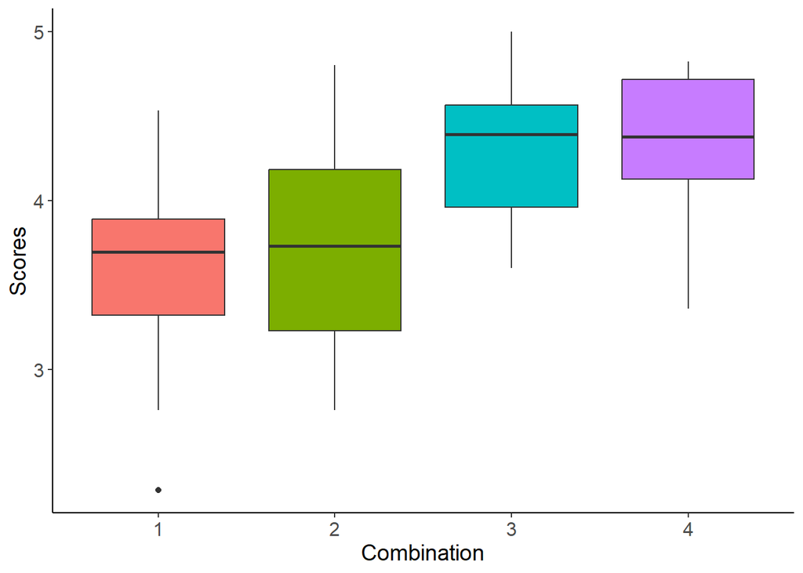

```r
sum_targets %>%
  ggplot(aes(x = combination, y = score, fill = combination)) +
  geom_boxplot() +
  theme_classic() +
  labs(x = 'Combination', y = 'Scores') +
  theme(axis.title.x = element_text(size = 14),
        axis.title.y = element_text(size = 14),
        axis.text.x = element_text(size = 12),
        axis.text.y = element_text(size = 12),
        plot.title = element_text(hjust = 0.5, size = 12),
        legend.position = "none")
```

```r
aov_model_aver <- aov(sum_targets$score ~ sum_targets$combination)
summary(aov_model_aver)
```

```
##                         Df Sum Sq Mean Sq F value   Pr(>F)
## sum_targets$combination  3  6.609  2.2031   7.725 0.000191 ***
## Residuals               60 17.112  0.2852
## ---
## Signif. codes:  0 '***' 0.001 '**' 0.01 '*' 0.05 '.' 0.1 ' ' 1
```

```r
TukeyHSD(aov_model_aver)
```

```
##   Tukey multiple comparisons of means
##     95% family-wise confidence level
##
## Fit: aov(formula = sum_targets$score ~ sum_targets$combination)
##
## $`sum_targets$combination`
##            diff        lwr       upr     p adj
## 2-1 0.079285714 -0.4196604 0.5782318 0.9748658
## 3-1 0.675357143  0.1764110 1.1743033 0.0037834
## 4-1 0.684389881  0.1854438 1.1833360 0.0032665
## 3-2 0.596071429  0.0971253 1.0950176 0.0129726
## 4-2 0.605104167  0.1061580 1.1040503 0.0113358
## 4-3 0.009032738 -0.4899134 0.5079789 0.9999602
```

```r
shapiro.test(residuals(object = aov_model_aver))
```

```
##
##  Shapiro-Wilk normality test
##
## data:  residuals(object = aov_model_aver)
## W = 0.98576, p-value = 0.6707
```

Таким образом, значимые различия между комбинациями есть (p < 0.001). Различия видны между всеми парами комбинаций, которые различаются по признаку +-imp.

### 3.2.6. Выявление значимых факторов: модели

```r
null_model <- glm(score ~ 1, data = targets)
step(object = null_model,
     direction = "forward",
     scope = score ~ neg + imp + obj_mentioned + number)
```

```
## Start:  AIC=4823.8
## score ~ 1
##
##                 Df Deviance    AIC
## + imp            1   2090.9 4700.0
## <none>               2277.5 4823.8
## + number         1   2276.9 4825.4
## + obj_mentioned  1   2277.0 4825.5
## + neg            1   2277.2 4825.6
##
## Step:  AIC=4700.02
## score ~ imp
##
##                 Df Deviance    AIC
## <none>               2090.9 4700.0
## + number         1   2090.3 4701.6
## + obj_mentioned  1   2090.5 4701.7
## + neg            1   2090.7 4701.8
```

```
##
## Call:  glm(formula = score ~ imp, data = targets)
##
## Coefficients:
## (Intercept)         imp1
##       3.577        0.712
##
## Degrees of Freedom: 1471 Total (i.e. Null);  1470 Residual
## Null Deviance:       2277
## Residual Deviance: 2091  AIC: 4700
```

Самая лучшая модель - та, что только от императива. Попробуем построить полную модель со всеми предикторами, включая их взаимодействие между собой.

```r
full_model <- lm(score ~ neg * imp * obj_mentioned * number, data = targets)
summary(full_model)
```

```
##
## Call:
## lm(formula = score ~ neg * imp * obj_mentioned * number, data = targets)
##
## Residuals:
##     Min      1Q  Median      3Q     Max
## -3.4674 -0.5870  0.5326  0.7826  1.7174
##
## Coefficients:
##                                   Estimate Std. Error t value Pr(>|t|)
## (Intercept)                        3.58696    0.12369  28.998  < 2e-16 ***
## neg1                              -0.16304    0.17493  -0.932 0.351468
## imp1                               0.88043    0.17493   5.033 5.43e-07 ***
## obj_mentioned1                    -0.18478    0.17493  -1.056 0.290998
## numbersg                          -0.04348    0.17493  -0.249 0.803748
## neg1:imp1                          0.07609    0.24739   0.308 0.758462
## neg1:obj_mentioned1                0.65217    0.24739   2.636 0.008473 **
## imp1:obj_mentioned1               -0.02174    0.24739  -0.088 0.929989
## neg1:numbersg                      0.45652    0.24739   1.845 0.065189 .
## imp1:numbersg                     -0.39130    0.24739  -1.582 0.113928
## obj_mentioned1:numbersg            0.29348    0.24739   1.186 0.235698
## neg1:imp1:obj_mentioned1          -0.60870    0.34986  -1.740 0.082102 .
## neg1:imp1:numbersg                -0.06522    0.34986  -0.186 0.852150
## neg1:obj_mentioned1:numbersg      -1.31522    0.34986  -3.759 0.000177 ***
## imp1:obj_mentioned1:numbersg       0.29348    0.34986   0.839 0.401697
## neg1:imp1:obj_mentioned1:numbersg  0.76087    0.49478   1.538 0.124316
## ---
## Signif. codes:  0 '***' 0.001 '**' 0.01 '*' 0.05 '.' 0.1 ' ' 1
##
## Residual standard error: 1.186 on 1456 degrees of freedom
## Multiple R-squared:  0.1001, Adjusted R-squared:  0.09082
## F-statistic:  10.8 on 15 and 1456 DF,  p-value: < 2.2e-16
```

Помимо императива, значимым предиктором оказывается комбинация “отрицание + наличие упоминания прямого объекта в контексте”. Оценки таких предложений оказываются лучше. Посмотрим, что это за предложения:

```r
sentences %>%
  filter((type == 'target') & (obj_mentioned == 1) & (neg == 1)) %>%
  select(sentence)
```

| sentence |
| --- |
| Когда мне предлагают шоколадки, я никогда не беру. |
| Если он предложит тебе шоколадку, не бери. |
| Я бы с радостью сходила в кино, но не зовут. |
| Не зовите, я всё равно не услышу. |
| Мы ведь не можем уехать без флешки, не понимаю, почему он не ищет. |
| Мы можем уехать и без флешки, не ищи. |
| Те студенты, которые не сделали домашку сразу, не делают и на каникулах. |
| Если вы еще не сделали домашку, не делайте, она слишком сложная. |
| Мы вчера поставили ёлку, но Вася пока не украшает. |
| Мы уже поставили ёлку, но подожди, пока не украшай. |

[output cut: 6 more lines]

Наконец, построим модель со смешанными эффектами участника и предложения:

```r
lmer_model <- lmer(score ~ neg * imp * obj_mentioned * number + (1|participant_id) + (1|sent_id),
                   data = targets)
summary(lmer_model)
```

```
## Linear mixed model fit by REML. t-tests use Satterthwaite's method [
## lmerModLmerTest]
## Formula: score ~ neg * imp * obj_mentioned * number + (1 | participant_id) +
##     (1 | sent_id)
##    Data: targets
##
## REML criterion at convergence: 4340.7
##
## Scaled residuals:
##     Min      1Q  Median      3Q     Max
## -3.0607 -0.5146  0.1173  0.6488  2.5867
##
## Random effects:
##  Groups         Name        Variance Std.Dev.
##  participant_id (Intercept) 0.3003   0.5480
##  sent_id        (Intercept) 0.2290   0.4785
##  Residual                   0.9234   0.9609
## Number of obs: 1472, groups:  participant_id, 92; sent_id, 64
##
## Fixed effects:
##                                   Estimate Std. Error       df t value Pr(>|t|)
## (Intercept)                        3.64453    0.26661 48.90068  13.670   <2e-16
## neg1                              -0.15137    0.36811 44.40496  -0.411   0.6829
## imp1                               0.83291    0.36811 44.40496   2.263   0.0286
## obj_mentioned1                    -0.24340    0.36811 44.40496  -0.661   0.5119
## numbersg                          -0.01247    0.36811 44.40496  -0.034   0.9731
## neg1:imp1                          0.02667    0.52059 44.40496   0.051   0.9594
## neg1:obj_mentioned1                0.69907    0.52059 44.40496   1.343   0.1861
## imp1:obj_mentioned1                0.01150    0.52059 44.40496   0.022   0.9825
## neg1:numbersg                      0.36884    0.52059 44.40496   0.708   0.4823
## imp1:numbersg                     -0.49358    0.52059 44.40496  -0.948   0.3482
## obj_mentioned1:numbersg            0.27411    0.52059 44.40496   0.527   0.6011
## neg1:imp1:obj_mentioned1          -0.59318    0.73623 44.40496  -0.806   0.4247
## neg1:imp1:numbersg                 0.13446    0.73623 44.40496   0.183   0.8559
## neg1:obj_mentioned1:numbersg      -1.23129    0.73623 44.40496  -1.672   0.1015
## imp1:obj_mentioned1:numbersg       0.38040    0.73623 44.40496   0.517   0.6079
## neg1:imp1:obj_mentioned1:numbersg  0.53625    1.04119 44.40496   0.515   0.6091
##
## (Intercept)                       ***
## neg1
## imp1                              *
## obj_mentioned1
## numbersg
## neg1:imp1
## neg1:obj_mentioned1
## imp1:obj_mentioned1
## neg1:numbersg
## imp1:numbersg
## obj_mentioned1:numbersg
## neg1:imp1:obj_mentioned1
## neg1:imp1:numbersg
## neg1:obj_mentioned1:numbersg
## imp1:obj_mentioned1:numbersg
## neg1:imp1:obj_mentioned1:numbersg
## ---
## Signif. codes:  0 '***' 0.001 '**' 0.01 '*' 0.05 '.' 0.1 ' ' 1
```

В этой модели только фактор императива оказывается статистически значимым (p = 0.03).

# 4. Заключение

Таким образом, из исследуемых факторов только наличие императива значимо влияет на грамматичность предложений с опущенным прямым объектом. Тем не менее, мы нашли фактор, который регулирует эллипсис прямого объекта в русском языке.